# Report from an initial data examination

Two main recommendations:

- **Consider focusing resources on some locations**
- **Let's work together on data quality to ensure relevant action**

### Current situation

- From the 12 districts studied, 11 see the most incidents in the category "Larceny and Vandalism".</sup>
- Districts where incidents happen farther away from the police station (Charlestown, South Boston...) don't have more incidents taking place
- Looking at data as shared by Mayor's office, some incidents seem double-counted: on an initial dataset of length 237221, we estimate that 11337 are duplicates, i.e. 4.78 %
- The incidents are typically looked at in aggregate since beginning of data collection

### Current situation: illustration

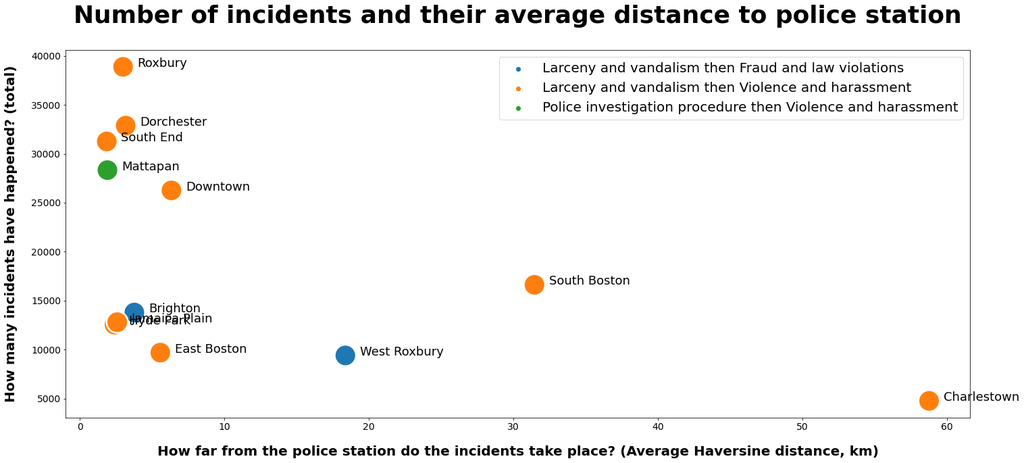

```python
distance_and_incidents_graph()
```

Recommendation n° 1

# Focusing resources on some locations

- While the police stations are close to where most incidents happen, some additional information is worth collecting:
  - How many police(wo)men by inhabitants are there in the various stations? Maybe some districts are understaffed
  - What is the typical tenure at the most incident-prone districts? Maybe the most experienced police(wo)men avoid them
  - What is the typical distance from nearest available police(wo)men to incident?
- Depending on the answers to those questions, it might be worth considering staffing more some districts or reorganizing the circulation of police cars

Recommendation n° 2:

# Let's work together on data quality to ensure relevant action

- It is possible that incidents are curently surestimated (duplicates). Let's ensure there are no duplicates in incident reporting
- Let's systematically look at the number of incidents over the course of a year or a month, and not since the beginning of data collection: this will ensure we can detect trends and focus efforts on those districts that *currently* need it the most
- Let's use map-based data exploration to better understand the dynamics of incidents versus police forces location